# What can Twitter tell us about Presdietnt Trump

## *Getting Started*

President Trump is no doubt one of the most controversial president in American history. From his healthcare plan to the massive potential for conflict of interest with his business and international pplitics, have you ever wonder how the nation felt on these particular issues? My project focuses exactly on that – using twitter history to evaluate people’s feelings towards President Trmup.

## *@realDonaldTrump*

First we will look at what people are twitting about President Trump using the code

```r
trump<-searchTwitter("@realDonaldTrump", n=3200)
```

After pulling the data, we will transfrom the list of tweets into a data frame for us to analyze

```r
tweet.df<-twListToDF(trump)
```

Based on the data I received from twitter, we can see what people are saying about President Trump using the wordcloud.

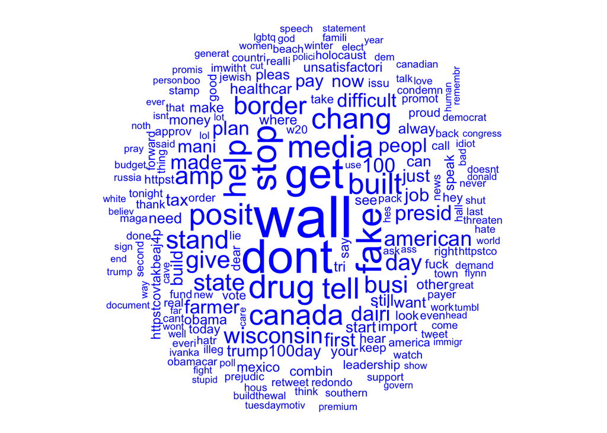

```r
wordcloud(wordCorpus,max.words=200,random.order=FALSE,random.color=TRUE,colors="blue")
```

We can get a general idea of what people are saying when they mention President Trump on twitter. However, it’s hard to differentiate between trump supporters from the rest of population, therefore we can do a sentiment analysis to see how people feel about President Trump.

### Sentiment Analysis

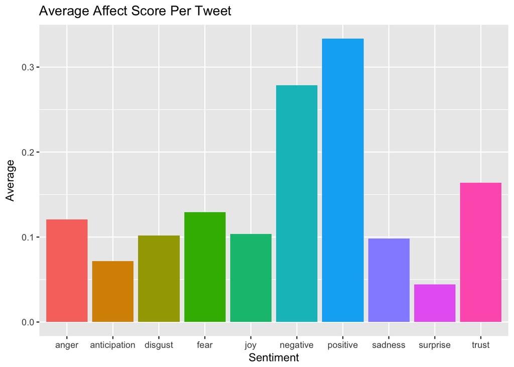

```r
ggplot(data = sentimentTotals, aes(x = sentiment, y = count)) +
geom_bar(aes(fill = sentiment), stat = "identity") +
theme(legend.position = "none") +
xlab("Sentiment") + ylab("Average") + ggtitle("Average Affect Score Per Tweet")
```

## President Trump

Looking at what people are saying about President Trump is interesting, but I’m also interested in what President himself tweets about. Let’s pull data from President Trump’s twitter.

```r
dtrump<-userTimeline('realdonaldtrump',n=3200)
trumpdf<-twListToDF(dtrump)
```

Now let’s use a wordcloud to get an idea on the words he uses most often

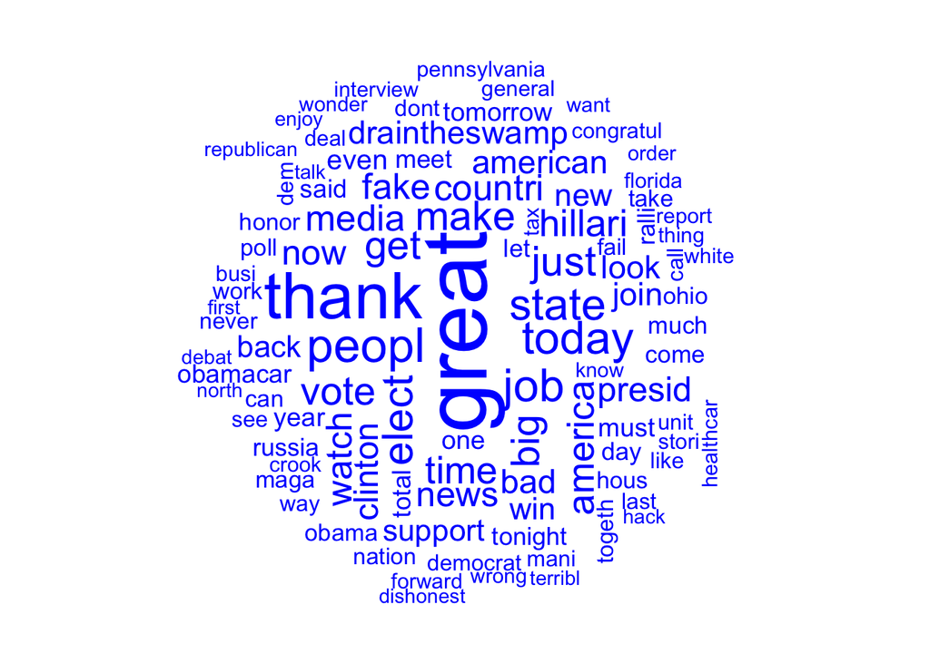

```r
wordcloud(wordCorpus,max.words=100,random.order=FALSE,random.color=TRUE,colors="blue")
```

No suprise that our President’s favorite words are “thank you” and “make America great again”. It’s very easy to pull out our President’s go-to words and slogans using wordcloud.

### Trump’s top ten tweets

I’m also curious out of all the tweets, which ones gets most favorite and retweet, so let’s look at President Trump’s top ten tweets

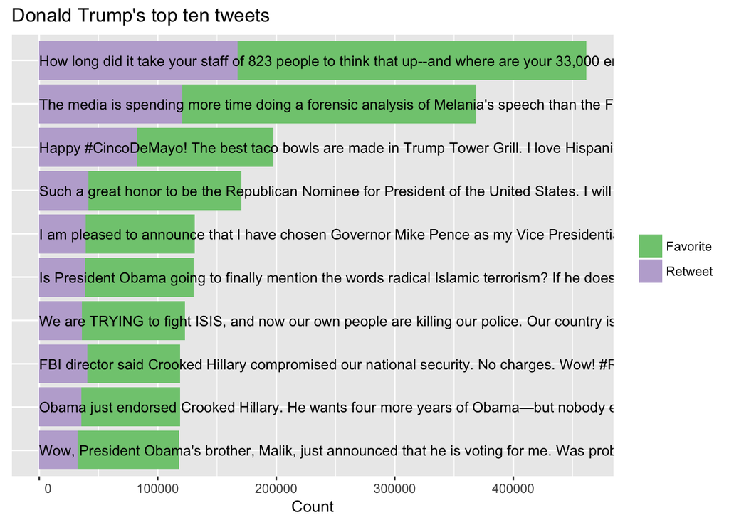

```r
bar.graph.data %>% filter(rank <= 10) %>%
  ggplot(aes(x = text, y = popularity, fill = type)) +
  geom_bar(stat = "identity") + coord_flip() +
  scale_fill_brewer(palette = "Accent",
                    guide = guide_legend(title = NULL),
                    limits = c("favorite_count", "retweet_count"),
                    labels = c("Favorite", "Retweet")) +
  scale_y_continuous(labels = function(x){format(x, scientific = FALSE)}) +
  geom_text(aes(label = text.as.character), size = 3.5, hjust = 0) +
  ylab("Count") +
  ggtitle("Donald Trump's top ten tweets") +
  theme(axis.title.y = element_blank(),
        axis.text.y = element_blank(),
        axis.ticks.y = element_blank())
```

### Sentiment Analysis

Now let’s do a sentiment analysis

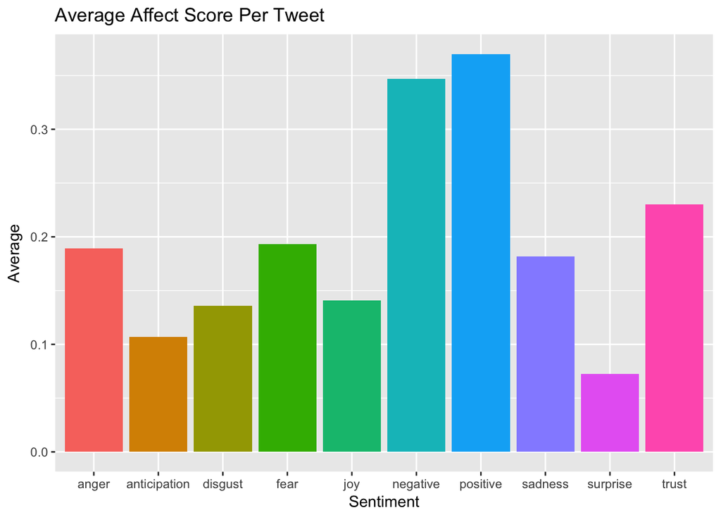

```r
ggplot(data = sentimentTotals1, aes(x = sentiment, y = count)) +
geom_bar(aes(fill = sentiment), stat = "identity") +
theme(legend.position = "none") +
xlab("Sentiment") + ylab("Average") + ggtitle("Average Affect Score Per Tweet")
```

Now I’m curious about what people notice most from President Trump’s tweet, so I decided to conduct a correlation test.

```r
corr.test(c)
```

```
## Call:corr.test(x = c)
## Correlation matrix
##               anger anticipation disgust fear   joy sadness surprise trust
## anger          1.00         0.19    0.71 0.75  0.15    0.65     0.23  0.16
## anticipation   0.19         1.00    0.03 0.10  0.63    0.15     0.54  0.46
## disgust        0.71         0.03    1.00 0.64  0.03    0.62     0.14  0.06
## fear           0.75         0.10    0.64 1.00  0.10    0.68     0.17  0.17
## joy            0.15         0.63    0.03 0.10  1.00    0.13     0.50  0.65
## sadness        0.65         0.15    0.62 0.68  0.13    1.00     0.28  0.16
## surprise       0.23         0.54    0.14 0.17  0.50    0.28     1.00  0.38
## trust          0.16         0.46    0.06 0.17  0.65    0.16     0.38  1.00
## negative       0.58         0.11    0.65 0.59  0.07    0.75     0.22  0.16
## positive       0.11         0.37    0.00 0.09  0.62    0.09     0.28  0.67
## favoritecount  0.06        -0.03    0.06 0.09 -0.03    0.08    -0.01 -0.03
## retweetcount   0.05        -0.02    0.04 0.08 -0.04    0.06     0.01 -0.03
##               negative positive favoritecount retweetcount
## anger             0.58     0.11          0.06         0.05
## anticipation      0.11     0.37         -0.03        -0.02
## disgust           0.65     0.00          0.06         0.04
## fear              0.59     0.09          0.09         0.08
## joy               0.07     0.62         -0.03        -0.04
## sadness           0.75     0.09          0.08         0.06
## surprise          0.22     0.28         -0.01         0.01
## trust             0.16     0.67         -0.03        -0.03
## negative          1.00     0.08          0.09         0.06
## positive          0.08     1.00         -0.01        -0.06
## favoritecount     0.09    -0.01          1.00         0.85
## retweetcount      0.06    -0.06          0.85         1.00
## Sample Size
## [1] 787
## Probability values (Entries above the diagonal are adjusted for multiple tests.)
##               anger anticipation disgust fear  joy sadness surprise trust
## anger          0.00         0.00    0.00 0.00 0.00    0.00     0.00  0.00
## anticipation   0.00         0.00    1.00 0.13 0.00    0.00     0.00  0.00
## disgust        0.00         0.33    0.00 0.00 1.00    0.00     0.00  1.00
## fear           0.00         0.00    0.00 0.00 0.20    0.00     0.00  0.00
## joy            0.00         0.00    0.48 0.01 0.00    0.01     0.00  0.00
## sadness        0.00         0.00    0.00 0.00 0.00    0.00     0.00  0.00
## surprise       0.00         0.00    0.00 0.00 0.00    0.00     0.00  0.00
## trust          0.00         0.00    0.07 0.00 0.00    0.00     0.00  0.00
## negative       0.00         0.00    0.00 0.00 0.04    0.00     0.00  0.00
## positive       0.00         0.00    0.93 0.01 0.00    0.01     0.00  0.00
## favoritecount  0.12         0.37    0.08 0.01 0.41    0.03     0.71  0.37
## retweetcount   0.14         0.52    0.22 0.03 0.25    0.10     0.88  0.45
##               negative positive favoritecount retweetcount
## anger             0.00     0.07          1.00         1.00
## anticipation      0.05     0.00          1.00         1.00
## disgust           0.00     1.00          1.00         1.00
## fear              0.00     0.33          0.31         0.72
## joy               0.93     0.00          1.00         1.00
## sadness           0.00     0.29          0.62         1.00
## surprise          0.00     0.00          1.00         1.00
## trust             0.00     0.00          1.00         1.00
## negative          0.00     0.45          0.30         1.00
## positive          0.02     0.00          1.00         1.00
## favoritecount     0.01     0.83          0.00         0.00
## retweetcount      0.07     0.10          0.00         0.00
##
##  To see confidence intervals of the correlations, print with the short=FALSE option
```

```r
favoritecount<-lm(favoritecount~disgust+sadness,c)
summary(favoritecount)
```

```
##
## Call:
## lm(formula = favoritecount ~ disgust + sadness, data = c)
##
## Residuals:
##    Min     1Q Median     3Q    Max
## -73962 -35889 -11215  23502 554989
##
## Coefficients:
##             Estimate Std. Error t value Pr(>|t|)
## (Intercept)    75039       2134  35.154   <2e-16 ***
## disgust         3068       6509   0.471    0.637
## sadness         8224       5716   1.439    0.151
## ---
## Signif. codes:  0 '***' 0.001 '**' 0.01 '*' 0.05 '.' 0.1 ' ' 1
##
## Residual standard error: 54970 on 784 degrees of freedom
## Multiple R-squared:  0.006491,   Adjusted R-squared:  0.003957
## F-statistic: 2.561 on 2 and 784 DF,  p-value: 0.07785
```

Now let’s look at the regression model for retweets

```r
retweetcount<-lm(retweetcount~negative,c)
summary(retweetcount)
```

```
##
## Call:
## lm(formula = retweetcount ~ negative, data = c)
##
## Residuals:
##    Min     1Q Median     3Q    Max
## -14810  -8094  -3551   3225 323497
##
## Coefficients:
##             Estimate Std. Error t value Pr(>|t|)
## (Intercept)  18545.0      730.5   25.39   <2e-16 ***
## negative      1862.0     1023.3    1.82   0.0692 .
## ---
## Signif. codes:  0 '***' 0.001 '**' 0.01 '*' 0.05 '.' 0.1 ' ' 1
##
## Residual standard error: 17910 on 785 degrees of freedom
## Multiple R-squared:  0.0042, Adjusted R-squared:  0.002931
## F-statistic: 3.311 on 1 and 785 DF,  p-value: 0.06922
```

Now, I’ll create a graph to visually show how negative sentiment are corrleated with retweets. Additionally, I will plot disgust as the color variation in the graph to see if that give us more insight.

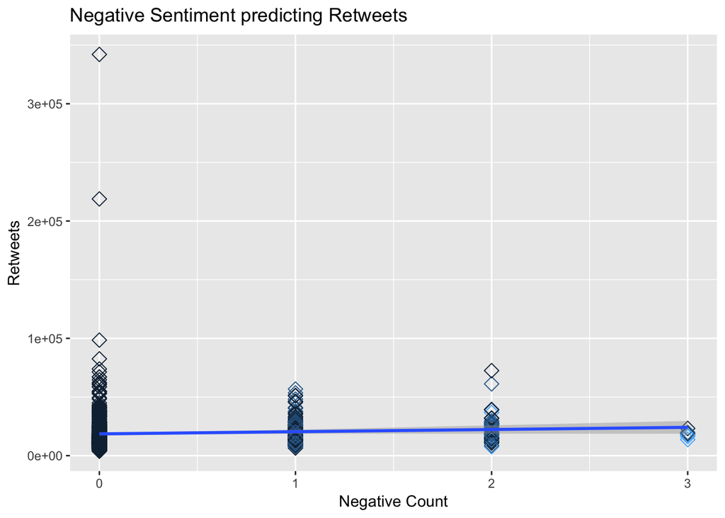

```r
ggplot(data=c,aes(x=negative,y=retweetcount,color=disgust))+
geom_point(size=3,shape=5)+
scale_y_continuous("Retweets")+
geom_smooth(data=c,method="lm")+
theme(legend.position="none")+
xlab("Negative Count") + ggtitle("Negative Sentiment predicting Retweets")
```

Same for the favorite counts, I will use disgust as predictor and sadness as the color variation.

[figure not shown]

```r
ggplot(data=c,aes(x=disgust,y=favoritecount,color=sadness))+
  geom_point(size=3,shape=5)+
  scale_y_continuous("Retweets")+
  geom_smooth(data=c,method="lm")+
  theme(legend.position="none")+
  xlab("Favorite Count") + ggtitle("Negative Sentiment predicting Favoritetweets")
```

### Principle Components

Let’s use what’s called principle components to give us a better understanding of how President Trump group his sentiments together.

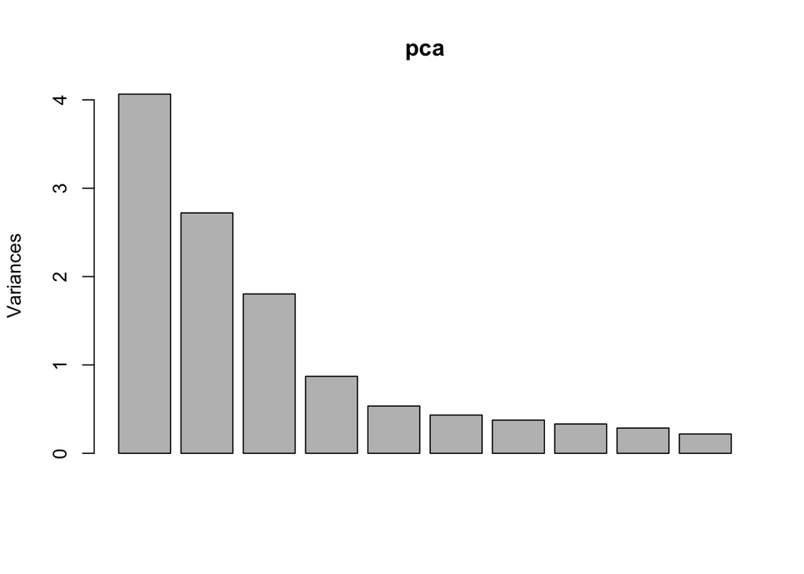

```r
pca<-prcomp(c,scale=TRUE)
plot(pca)
```

The distribution of variance is not ideal, but it’s something we can live with. now let’s try to plot the variance from the first two factors to see if that will give us more insight

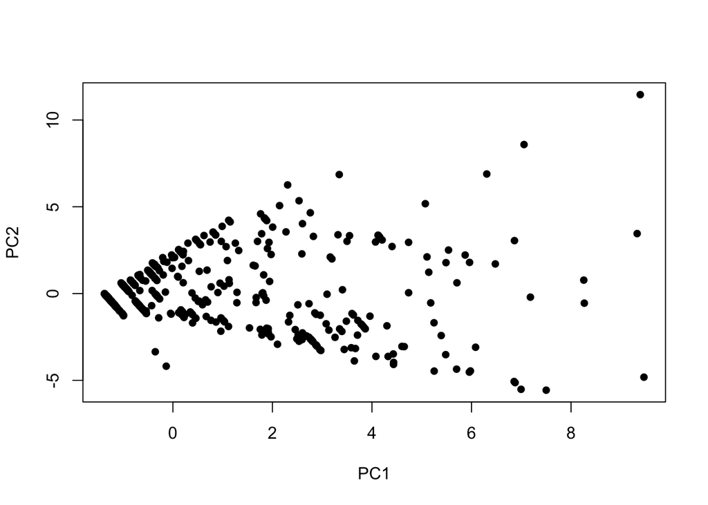

```r
x32<-summary(pca)$x[,1:2]
plot(x32,pch=16)
```

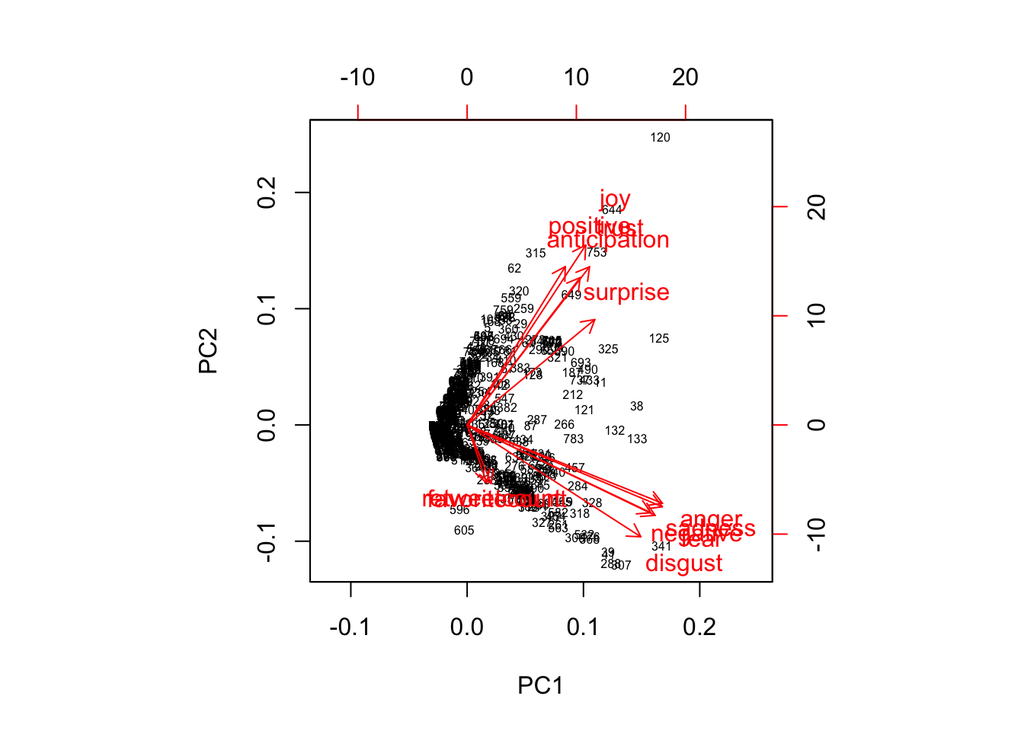

```r
p<-biplot(pca,cex=c(0.5,1))
```

Here you can see often time, joy, positive, anticipation, surprise and trust gets group together, and angery, negative, disgust group together near fewer retweet and favorite counts.

To gain more insight of how Trump group his sentiments together, we will look at another graph

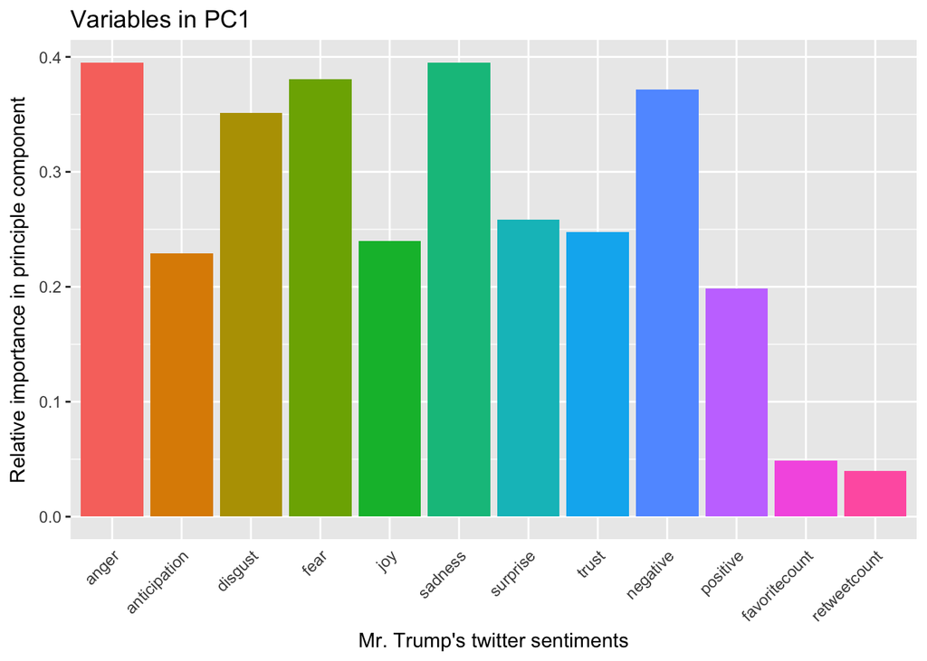

```r
ggplot(data = melted[melted$Var2 == "PC1",]) +
theme(legend.position = "none",
axis.text.x= element_text(angle=45, hjust = 1),
axis.ticks.x = element_blank()) +
xlab("Mr. Trump's twitter sentiments") +
ylab("Relative importance in principle component") +
ggtitle("Variables in PC1") +
geom_bar(aes(x=Var1, y=value, fill=Var1), stat="identity")
```

PC1 shows us how things generally increase with one another, it’s interesting how this seems to be counter intuitive to what we discovered in the regression model. Let’s check PC2 and PC3.

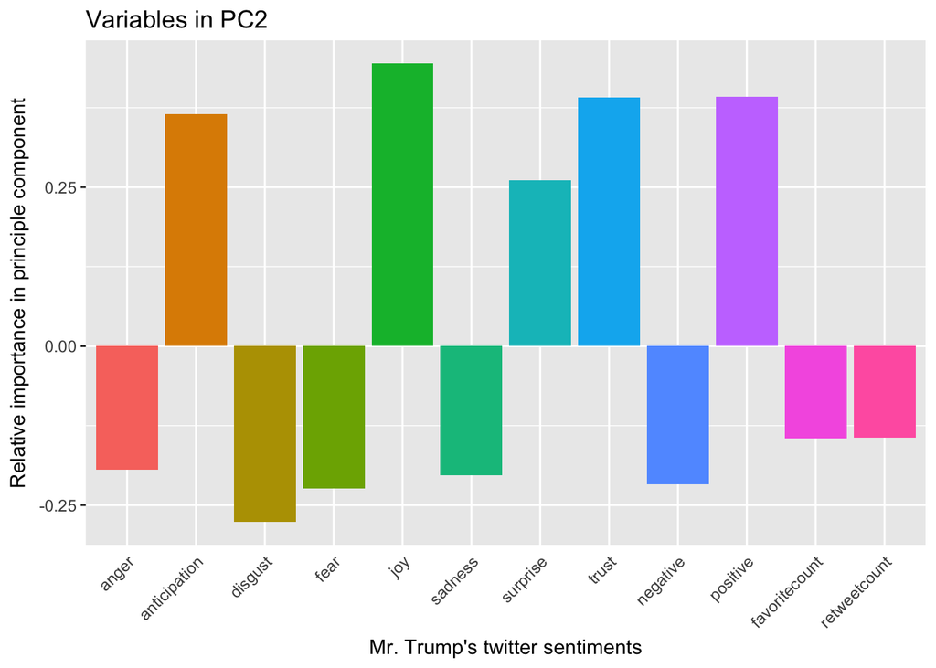

```r
ggplot(data = melted[melted$Var2 == "PC2",]) +
theme(legend.position = "none",
axis.text.x= element_text(angle=45, hjust = 1),
axis.ticks.x = element_blank()) +
xlab("Mr. Trump's twitter sentiments") +
ylab("Relative importance in principle component") +
ggtitle("Variables in PC2") +
geom_bar(aes(x=Var1, y=value, fill=Var1), stat="identity")
```

From PC2 we can see how negative emotions group together with favotie and retweet counts.

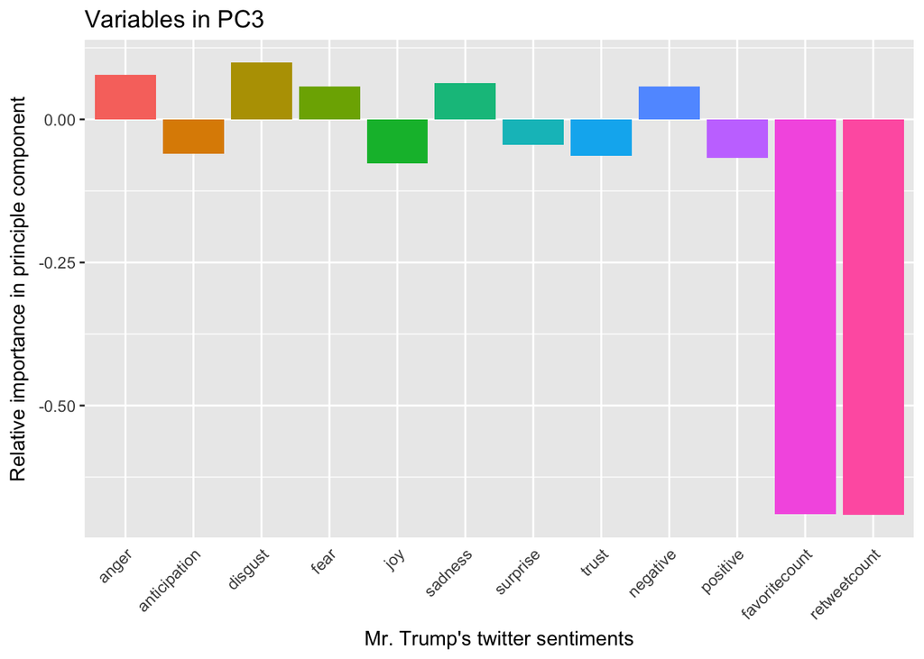

```r
ggplot(data = melted[melted$Var2 == "PC3",]) +
theme(legend.position = "none",
axis.text.x= element_text(angle=45, hjust = 1),
axis.ticks.x = element_blank()) +
xlab("Mr. Trump's twitter sentiments") +
ylab("Relative importance in principle component") +
ggtitle("Variables in PC3") +
geom_bar(aes(x=Var1, y=value, fill=Var1), stat="identity")
```

The third analysis of variance gives us an idea of why so much of the variance went into third variables, favorite count and retweet counts are highly corrleated and share their own variance, this is highly unique from the rest of the variables.

### I hope this project provide you an interesting insight of what people are saying about Trump!